# Разработка модели машинного обучения с целью расширения поголовья стада коров

**Посмотрим распредление удоя в зависимости от показателя отношения сахара к протеину в корме коровы**

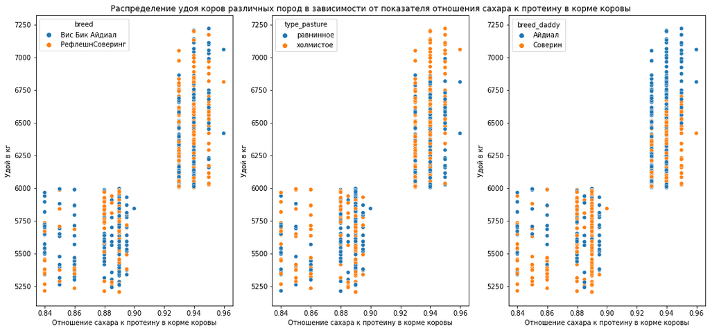

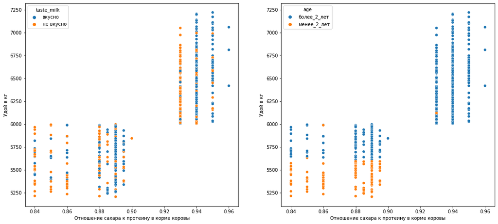

```python
fig, axes=plt.subplots(nrows=1,ncols=3, figsize=(18,8))
sns.scatterplot(x=main_dad['sugar_protein_ratio'], y=main_dad['yield_kg'], hue=main_dad['breed'], ax=axes[0])
axes[0].set_xlabel('Отношение сахара к протеину в корме коровы')
axes[0].set_ylabel('Удой в кг')

sns.scatterplot(x=main_dad['sugar_protein_ratio'], y=main_dad['yield_kg'], hue=main_dad['type_pasture'], ax=axes[1])
axes[1].set_xlabel('Отношение сахара к протеину в корме коровы')
axes[1].set_ylabel('Удой в кг')
axes[1].set_title('Распределение удоя коров различных пород в зависимости от показателя отношения сахара к протеину в корме коровы')

sns.scatterplot(x=main_dad['sugar_protein_ratio'], y=main_dad['yield_kg'], hue=main_dad['breed_daddy'], ax=axes[2])
axes[2].set_xlabel('Отношение сахара к протеину в корме коровы')
axes[2].set_ylabel('Удой в кг')
plt.show()

fig, axes=plt.subplots(nrows=1,ncols=2, figsize=(18,8))
sns.scatterplot(x=main_dad['sugar_protein_ratio'], y=main_dad['yield_kg'], hue=main_dad['taste_milk'], ax=axes[0])
axes[0].set_xlabel('Отношение сахара к протеину в корме коровы')
axes[0].set_ylabel('Удой в кг')

sns.scatterplot(x=main_dad['sugar_protein_ratio'], y=main_dad['yield_kg'], hue=main_dad['age'], ax=axes[1])
axes[1].set_xlabel('Отношение сахара к протеину в корме коровы')
axes[1].set_ylabel('Удой в кг')
plt.show()
```

По данному графику можно судить о наличии мультиколлинеарности. При разработке модели машиного обучения необходимо будет это учесть. Показатель отношения сахара к протеину в корме влияет больше на удой коров в возрасте более 2-х лет и у которых папа имеет породу "Айдиал", а также у коров, которые пасутся на холмистых лугах.

**Посмотрим распредление удоя в зависимости от содержания жиров в молоке (в процентах)**

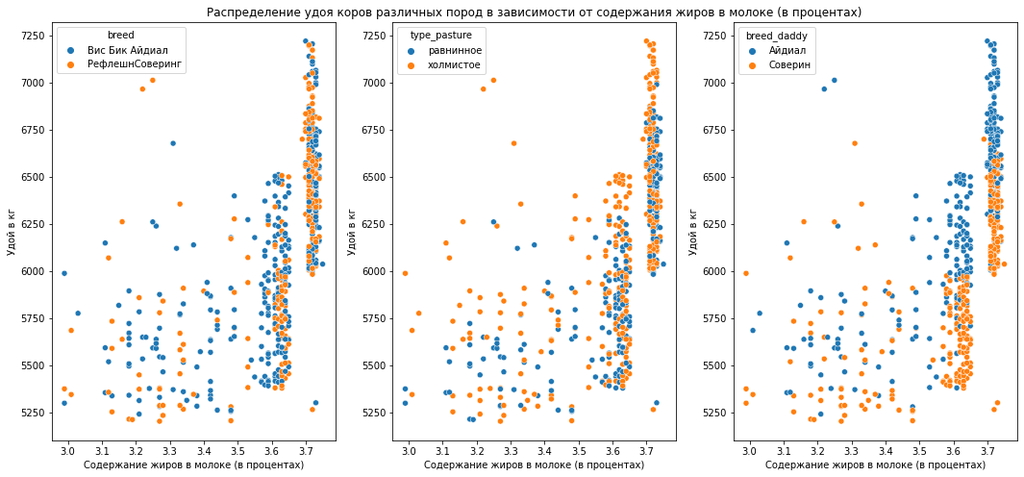

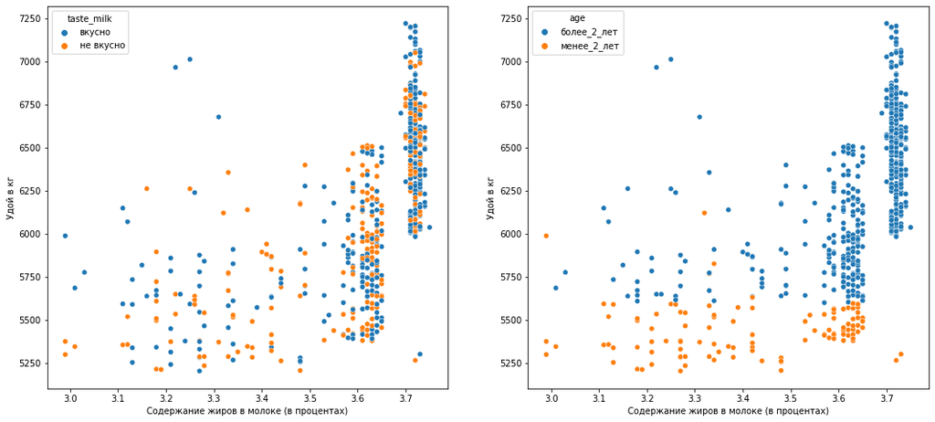

```python
fig, axes=plt.subplots(nrows=1,ncols=3, figsize=(18,8))
sns.scatterplot(x=main_dad['fat_perc'], y=main_dad['yield_kg'], hue=main_dad['breed'], ax=axes[0])
axes[0].set_xlabel('Cодержание жиров в молоке (в процентах)')
axes[0].set_ylabel('Удой в кг')

sns.scatterplot(x=main_dad['fat_perc'], y=main_dad['yield_kg'], hue=main_dad['type_pasture'], ax=axes[1])
axes[1].set_xlabel('Cодержание жиров в молоке (в процентах)')
axes[1].set_ylabel('Удой в кг')
axes[1].set_title('Распределение удоя коров различных пород в зависимости от содержания жиров в молоке (в процентах)')

sns.scatterplot(x=main_dad['fat_perc'], y=main_dad['yield_kg'], hue=main_dad['breed_daddy'], ax=axes[2])
axes[2].set_xlabel('Cодержание жиров в молоке (в процентах)')
axes[2].set_ylabel('Удой в кг')
plt.show()

fig, axes=plt.subplots(nrows=1,ncols=2, figsize=(18,8))
sns.scatterplot(x=main_dad['fat_perc'], y=main_dad['yield_kg'], hue=main_dad['taste_milk'], ax=axes[0])
axes[0].set_xlabel('Cодержание жиров в молоке (в процентах)')
axes[0].set_ylabel('Удой в кг')

sns.scatterplot(x=main_dad['fat_perc'], y=main_dad['yield_kg'], hue=main_dad['age'], ax=axes[1])
axes[1].set_xlabel('Cодержание жиров в молоке (в процентах)')
axes[1].set_ylabel('Удой в кг')
plt.show()
```

По данному графику можно судить о линейной зависимости, но также и мультиколлинеарности. При разработке модели машинного обучения необходимо будет это учесть. Показатель содержания жиров в молоке влияет больше на удой коров в возрасте более 2-х лет и у которых папа имеет породу "Айдиал", а также у коров, которые пасутся на холмистых лугах.

**Посмотрим распредление удоя в зависимости от содержания белков в молоке (в процентах)**

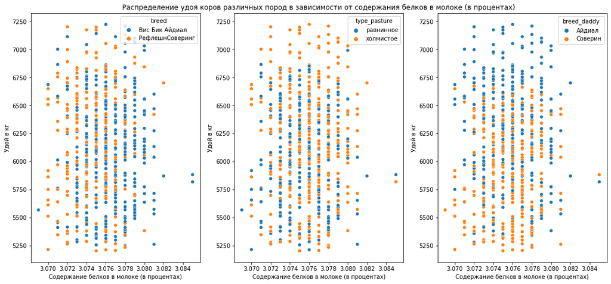

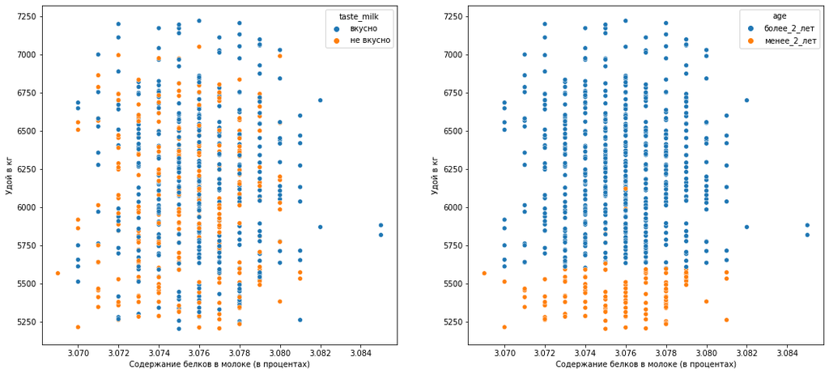

```python
fig, axes=plt.subplots(nrows=1,ncols=3, figsize=(18,8))
sns.scatterplot(x=main_dad['protein_perc'], y=main_dad['yield_kg'], hue=main_dad['breed'], ax=axes[0])
axes[0].set_xlabel('Cодержание белков в молоке (в процентах)')
axes[0].set_ylabel('Удой в кг')

sns.scatterplot(x=main_dad['protein_perc'], y=main_dad['yield_kg'], hue=main_dad['type_pasture'], ax=axes[1])
axes[1].set_xlabel('Cодержание белков в молоке (в процентах)')
axes[1].set_ylabel('Удой в кг')
axes[1].set_title('Распределение удоя коров различных пород в зависимости от содержания белков в молоке (в процентах)')

sns.scatterplot(x=main_dad['protein_perc'], y=main_dad['yield_kg'], hue=main_dad['breed_daddy'], ax=axes[2])
axes[2].set_xlabel('Cодержание белков в молоке (в процентах)')
axes[2].set_ylabel('Удой в кг')
plt.show()

fig, axes=plt.subplots(nrows=1,ncols=2, figsize=(18,8))
sns.scatterplot(x=main_dad['protein_perc'], y=main_dad['yield_kg'], hue=main_dad['taste_milk'], ax=axes[0])
axes[0].set_xlabel('Cодержание белков в молоке (в процентах)')
axes[0].set_ylabel('Удой в кг')

sns.scatterplot(x=main_dad['protein_perc'], y=main_dad['yield_kg'], hue=main_dad['age'], ax=axes[1])
axes[1].set_xlabel('Cодержание белков в молоке (в процентах)')
axes[1].set_ylabel('Удой в кг')
plt.show()
```

По данному графику можно судить о наличии мультиколлинеарности. При разработке модели машинного обучения необходимо будет это учесть. Показатель содержания белков в молоке влияет больше на удой коров в возрасте более 2-х лет и у которых папа имеет породу "Айдиал".

**Посмотрим распредление удоя в зависимости от породы коровы**

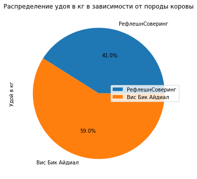

```python
yield_breed = main_dad.pivot_table(
    index='breed',
    values='yield_kg',
    aggfunc='sum').sort_values('yield_kg').plot(kind='pie',
                                                y='yield_kg',
                                                ylabel='Удой в кг',
                                                title = 'Распределение удоя в кг в зависимости от породы коровы',
                                                autopct='%1.1f%%', figsize=(6,6))
plt.legend(loc=5)
plt.show()
```

По круговой диаграмме видно, что наибольший объем удоя наблюдается у коров породы "Вик Бик Айдиал"

**Посмотрим распредление удоя в зависимости от ландшафта лугов, на которых паслась корова**

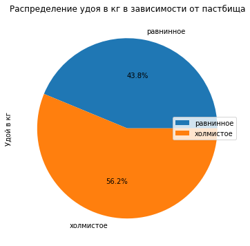

```python
yield_type_pasture = main_dad.pivot_table(
    index='type_pasture',
    values='yield_kg',
    aggfunc='sum').sort_values('yield_kg').plot(kind='pie',
                                                y='yield_kg',
                                                ylabel='Удой в кг',
                                                title = 'Распределение удоя в кг в зависимости от пастбища',
                                                autopct='%1.1f%%',
                                                figsize=(6,6))
plt.legend(loc=5)
plt.show()
```

По круговой диаграмме видно, что наибольший объем удоя наблюдается у тех коров, которые паслись на холмистых лугах.

**Посмотрим распредление удоя в зависимости от породы папы коровы**

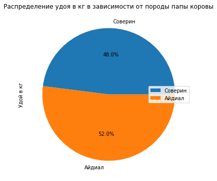

```python
yield_breed_daddy = main_dad.pivot_table(
    index='breed_daddy',
    values='yield_kg',
    aggfunc='sum').sort_values('yield_kg').plot(kind='pie',
                                                y='yield_kg',
                                                ylabel='Удой в кг',
                                                title = 'Распределение удоя в кг в зависимости от породы папы коровы',
                                                autopct='%1.1f%%',
                                                figsize=(6,6))
plt.legend(loc=5)
plt.show()
```

По круговой диаграмме видно, что наибольший объем удоя наблюдается у тех коров, порода папы которых является "Айдиал".

**Посмотрим распредление удоя в зависимости от вкуса молока**

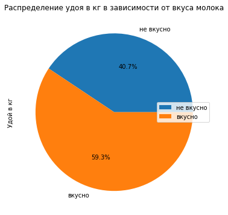

```python
yield_taste_milk = main_dad.pivot_table(
    index='taste_milk',
    values='yield_kg',
    aggfunc='sum').sort_values('yield_kg').plot(kind='pie',
                                                y='yield_kg',
                                                ylabel='Удой в кг',
                                                title = 'Распределение удоя в кг в зависимости от вкуса молока',
                                                autopct='%1.1f%%',
                                                figsize=(6,6))
plt.legend(loc=5)
plt.show()
```

По круговой диаграмме видно, что наибольший объем удоя наблюдается у тех коров, молоко у которых получается вкусным.

**Посмотрим распредление удоя в зависимости от возраста коровы**

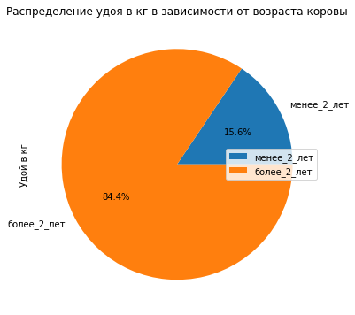

```python
yield_age = main_dad.pivot_table(
    index='age',
    values='yield_kg',
    aggfunc='sum').sort_values('yield_kg').plot(kind='pie',
                                                y='yield_kg',
                                                ylabel='Удой в кг',
                                                title = 'Распределение удоя в кг в зависимости от возраста коровы',
                                                autopct='%1.1f%%',
                                                figsize=(6,6))
plt.legend(loc=5)
plt.show()
```

По круговой диаграмме видно, что наибольший объем удоя наблюдается у тех коров, возраст которых более 2-х лет.

**Посмотрим распредление удоя в зависимости от имени папы коровы**

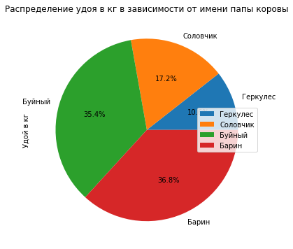

```python
yield_name_daddy = main_dad.pivot_table(
    index='name_daddy',
    values='yield_kg',
    aggfunc='sum').sort_values('yield_kg').plot(kind='pie',
                                                y='yield_kg',
                                                ylabel='Удой в кг',
                                                title = 'Распределение удоя в кг в зависимости от имени папы коровы',
                                                autopct='%1.1f%%',
                                                figsize=(6,6))
plt.legend(loc=5)
plt.show()
```

По круговой диаграмме видно, что наибольший объем удоя наблюдается у тех коров, имя папы коров которых является "Барин".

### Выводы по корреляционному анализу данных

По тепловой карте можно сделать следующие выводы о взаимосвязи между признаками:

- Высокая сила связи наблюдается между `energy_feed_unit` и `yield_kg`; `sugar_protein_ratio` и `yield_kg`; `sugar_protein_ratio` и `energy_feed_unit`.
- Средняя сила связи наблюдается между `fat_perc` и `yield_kg`; `fat_perc` и `energy_feed_unit`; `fat_perc` и `sugar_protein_ratio`.
- Слабая сила связи наблюдается между `raw_protein_g` и `yield_kg`; `raw_protein_g` и `energy_feed_unit`; `sugar_protein_ratio` и `raw_protein_g`; `fat_perc` и `raw_protein_g`.

По построенным диаграммам рассеивания можно сделать следующие выводы:

- Можно судить о положительной линейной зависимости между удоем и показателем питательности корма коровы. Причем, показатель питательности корма влияет больше на удой коров в возрасте более 2-х лет и у которых папа имеет породу "Айдиал".
- Сложно судить о линейной зависимости между удоем и содержанием сырого протеина в корме коровы. Связь прослеживается, но очень слабая. Показатель содержания сырого протеина в корме более выражено в объеме удоя у коров в возрасте более 2-лет и у которых папа имеет породу "Айдиал".
- Можно судить о наличии мультиколлинеарности между удоем и отношением сахара к протеину в корме коровы. При разработке модели машинного обучения необходимо будет это учесть. Показатель отношения сахара к протеину в корме влияет больше на удой коров в возрасте более 2-х лет и у которых папа имеет породу "Айдиал", а также у коров, которые пасутся на холмистых лугах.
- Можно судить о линейной зависимости между удоем и содержанием жиров в молоке, но также и мультиколлинеарности. При разработке модели машинного обучения необходимо будет это учесть. Показатель содержания жиров в молоке влияет больше на удой коров в возрасте более 2-х лет и у которых папа имеет породу "Айдиал", а также у коров, которые пасутся на холмистых лугах.
- Можно судить о наличии мультиколлинеарности между удоем и содержанием белков в молоке. При разработке модели машинного обучения необходимо будет это учесть. Показатель содержания белков в молоке влияет больше на удой коров в возрасте более 2-х лет и у которых папа имеет породу "Айдиал".

По построенным круговым диаграммам категореальных признаков можно сделать следующий вывод, что наибольший объем удоя наблюдается:

- у коров породы "Вик Бик Айдиал";
- у коров, которые паслись на холмистых лугах;
- у коров, порода папы которых является "Айдиал";
- у коров, молоко у которых получается вкусным;
- у коров, возраст которых более 2-х лет;
- у коров, имя папы коров которых является "Барин".

## Обучение модели линейной регрессии

На данном этапе необходимо выполнить следующие шаги:

- Подготовить данные датасетов и обучить на них три модели `LinearRegression`
- Сравнить качество трёх моделей линейной регрессии, сопоставить их R² и остатки.
- Оценить качество каждой модели по трём метрикам: MSE, MAE, RMSE
- С помощью лучшей модели спрогнозировать удой коров, которых фермер хочет купить. Данные о них находятся в датасете `cow_buy`.

### Подготовим данные и обучим на них первую модель `LinearRegression`

```python
main = main_dad.drop('name_daddy', axis=1)
```

```python
main.head()
```

|  | id | yield_kg | energy_feed_unit | raw_protein_g | sugar_protein_ratio | breed | type_pasture | breed_daddy | fat_perc | protein_perc | taste_milk | age |
| --- | --- | --- | --- | --- | --- | --- | --- | --- | --- | --- | --- | --- |
| 0 | 1 | 5863 | 14.2 | 1743 | 0.890 | Вис Бик Айдиал | равнинное | Айдиал | 3.58 | 3.076 | вкусно | более_2_лет |
| 1 | 2 | 5529 | 12.8 | 2138 | 0.890 | Вис Бик Айдиал | равнинное | Соверин | 3.54 | 3.079 | вкусно | менее_2_лет |
| 2 | 3 | 5810 | 14.0 | 1854 | 0.885 | РефлешнСоверинг | холмистое | Соверин | 3.59 | 3.074 | не вкусно | более_2_лет |
| 3 | 4 | 5895 | 12.4 | 2012 | 0.885 | РефлешнСоверинг | холмистое | Айдиал | 3.40 | 3.075 | не вкусно | более_2_лет |
| 4 | 5 | 5302 | 12.8 | 1675 | 0.885 | Вис Бик Айдиал | равнинное | Соверин | 3.73 | 3.073 | вкусно | менее_2_лет |

**Отберем признаки, которые подходят для модели линейной регрессии, с учетом причинно-следственных связей между удоем коров и группами признаков из описания датасета.**

К таким признакам отнесем:

- `energy_feed_unit` - показатель питательности корма коровы
- `raw_protein_g` - содержание сырого протеина в корме (в граммах)
- `sugar_protein_ratio` - отношение сахара к протеину в корме коровы
- `breed` - порода коровы
- `type_pasture` - ландшафт лугов, на которых паслась корова
- `breed_daddy` - порода папы коровы
- `age` - возраст коровы, бинарный признак (менее_2_лет, более_2_лет)

```python
# Зададим константу
RANDOM_STATE = 40
# Выделим в отдельные переменные входные и целевой признаки
X = main.drop('yield_kg', axis=1)
y = main['yield_kg']
# Разделим данные на тренировочные и тестовые выборки
X_train, X_test, y_train, y_test = train_test_split(X, y, random_state = RANDOM_STATE)
```

```python
# Проведем анализ категориальных признаков
cat_col_names = ['breed', 'type_pasture', 'breed_daddy', 'age']
X_train[cat_col_names].nunique()
```

```
breed           2
type_pasture    2
breed_daddy     2
age             2
dtype: int64
```

В данных четыре категориальных признака, в каждом по две категории. Далее кодируем эти данные, чтобы модель смогла с ними работать.

```python
cat_col_names = ['breed', 'type_pasture', 'breed_daddy', 'age']
# Создадим переменную с классом кодирования, включим параметр для избегания дамми-ошибок
encoder1 = OneHotEncoder(drop='first', sparse=False)
# Обучим и преобразуем категориальные признаки в тестовой выборке
X_train_ohe = encoder1.fit_transform(X_train[cat_col_names])
# Преобразуем категориальные признаки в тренировочной выборке
X_test_ohe = encoder1.transform(X_test[cat_col_names])
```

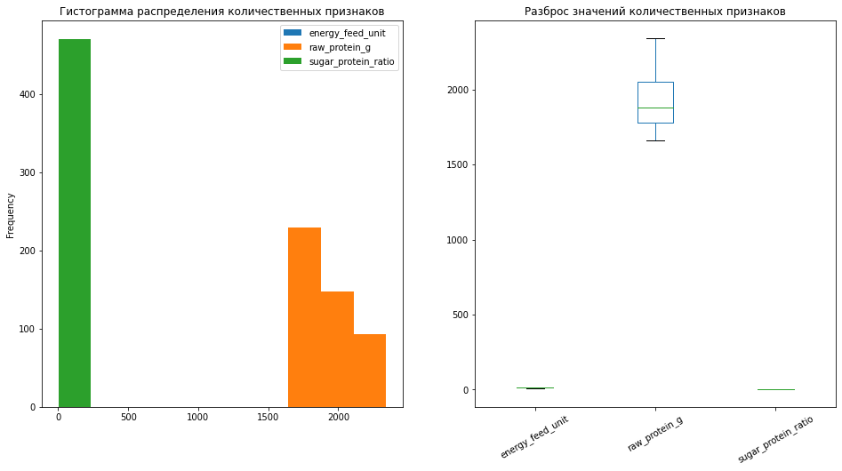

```python
# Проведем анализ количественных признаков
num_col_names = ['energy_feed_unit', 'raw_protein_g', 'sugar_protein_ratio']
fig, axes = plt.subplots(nrows=1, ncols=2, figsize=(16,8))
X_train[num_col_names].plot(kind='hist', bins=10, ax=axes[0])
axes[0].set_title('Гистограмма распределения количественных признаков')
X_train[num_col_names].plot(kind='box', ax=axes[1], rot=30)
axes[1].set_title('Разброс значений количественных признаков')
plt.show()
```

В датасете получилось три количественных признака и все они разного масштаба. Мвсштабируем далее эти данные, чтобы модель смогла с ними работать.

```python
num_col_names = ['energy_feed_unit', 'raw_protein_g', 'sugar_protein_ratio']
# Создадим переменную с классом стандартизации
scaler1 = StandardScaler()
# Обучим и преобразуем количественные признаки в тестовой выборке
X_train_scaler = scaler1.fit_transform(X_train[num_col_names])
# Преобразуем количественные признаки в тренировочной выборке
X_test_scaler = scaler1.transform(X_test[num_col_names])
```

После того, как данные закодированы и масштабированы, объединим подготовленные количественные и категориальные данные в датафрейм, выполним прогнозирование данных по тестовой выборке и рассчитаем коэфиициент детерминации.

```python
# Выведем список новых столбцов после кодирования
encoder_col_names = encoder1.get_feature_names()

X_train_ohe = pd.DataFrame(X_train_ohe, columns=encoder_col_names)
X_test_ohe = pd.DataFrame(X_test_ohe, columns=encoder_col_names)

X_train_scaler = pd.DataFrame(X_train_scaler, columns=num_col_names)
X_test_scaler = pd.DataFrame(X_test_scaler, columns=num_col_names)

X_train = pd.concat([X_train_ohe, X_train_scaler], axis=1)
X_test = pd.concat([X_test_ohe, X_test_scaler], axis=1)
```

```python
display(X_train.head(2))
display(X_test.head(2))
```

|  | x0_РефлешнСоверинг | x1_холмистое | x2_Соверин | x3_менее_2_лет | energy_feed_unit | raw_protein_g | sugar_protein_ratio |
| --- | --- | --- | --- | --- | --- | --- | --- |
| 0 | 1.0 | 0.0 | 1.0 | 0.0 | 0.608915 | 0.295138 | -0.670147 |
| 1 | 0.0 | 1.0 | 0.0 | 0.0 | 0.457530 | 0.494492 | 0.871061 |

|  | x0_РефлешнСоверинг | x1_холмистое | x2_Соверин | x3_менее_2_лет | energy_feed_unit | raw_protein_g | sugar_protein_ratio |
| --- | --- | --- | --- | --- | --- | --- | --- |
| 0 | 1.0 | 1.0 | 0.0 | 0.0 | -0.602166 | 1.613086 | -0.516026 |
| 1 | 0.0 | 0.0 | 1.0 | 1.0 | -2.040325 | -1.316301 | -2.211355 |

Убедимся в правильности выполнения масштабирования. Для этого построим еще раз гистограмму распределения и ящик с усами количественных признаков.

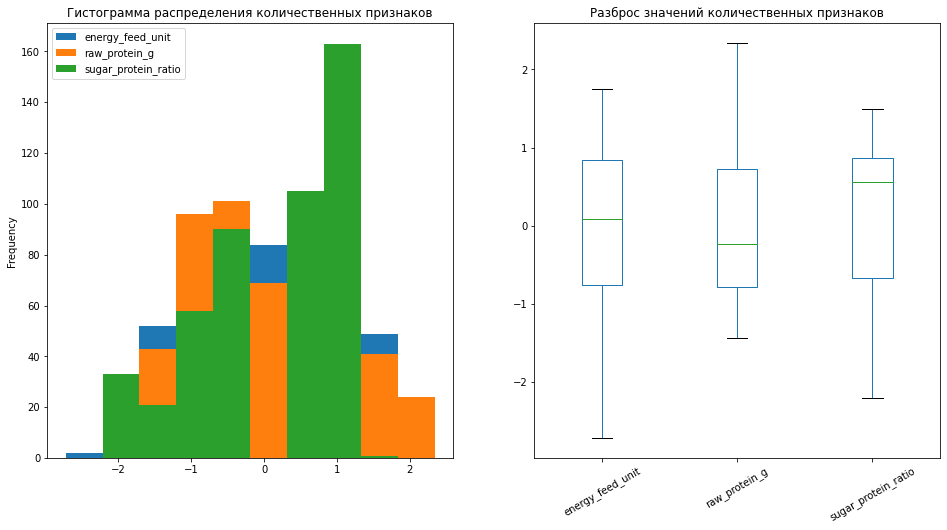

```python
fig, axes = plt.subplots(nrows=1, ncols=2, figsize=(16,8))
X_train_scaler.plot(kind='hist', bins=10, ax=axes[0])
axes[0].set_title('Гистограмма распределения количественных признаков')
X_train_scaler.plot(kind='box', ax=axes[1], rot=30)
axes[1].set_title('Разброс значений количественных признаков')
plt.show()
```

Данные отмасштабированы. Теперь можно приступить к прогнозированию данных.

```python
# Инициализируем модель линейной регрессии
model_lr = LinearRegression()
model_lr.fit(X_train, y_train)
# Получим предсказания модели на тестовых данных
predictions1 = model_lr.predict(X_test)
```

```python
# Рассчитаем коэффициент детерминации
r2_1 = r2_score(y_test, predictions1)
print("Коэффициент детерминации первой модели =", r2_1)
```

```
Коэффициент детерминации первой модели = 0.8054570703263173
```

Полученный коээфициент детерминации говорит о том, что модель хорошо себя показывает в 81% предсказаний.

**Проведем анализ остатков первой модели.**

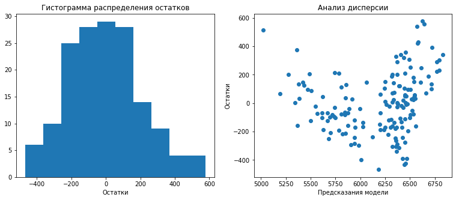

```python
# Рассчитайте остатки
residuals1 = y_test - predictions1
# Построим графики по количественным признакам - гистограмму частотности расперделения и диаграмму рассеяния
fig, axes = plt.subplots(nrows=1, ncols=2, figsize=(13,5))
axes[0].hist(residuals1)
axes[0].set_title('Гистограмма распределения остатков')
axes[0].set_xlabel('Остатки')

axes[1].scatter(x = predictions1, y = residuals1)
axes[1].set_title('Анализ дисперсии')
axes[1].set_xlabel('Предсказания модели')
axes[1].set_ylabel('Остатки')
plt.show()
```

Гистограмма распределения остатков показывает распределение близкое к нормальному, но присутствует явная ассиметрия, то есть у модели стабильная ошибка в большинстве предсказаний. По анализу дисперсии можно сказать, что разброс остатков более склонен к непостоянству. Модель стоит улучшать.

**Оценим качество первой модели - рассчитаем метрики MSE, MAE, RMSE**

```python
mse1 = mean_squared_error(y_test, predictions1)
mae1 = mean_absolute_error(y_test, predictions1)
rmse1 = mean_squared_error(y_test, predictions1, squared=False)
print(f"MSE первой модели = {mse1:.2f}")
print(f"MAE первой модели = {mae1:.2f}")
print(f"RMSE первой модели = {rmse1:.2f}")
```

```
MSE первой модели = 44271.23
MAE первой модели = 167.78
RMSE первой модели = 210.41
```

В среднем, первая модель ошибается, примерно, на 167.78 - 210.41 кг.

### Подготовим данные и обучим на них вторую модель `LinearRegression`

По диаграммам рассеяния в пункте 4.2 видно, что СПО и Удой связаны нелинейно. На их диаграмме рассеяния наблюдения сгруппированы в два кластера. Для этого преобразуем СПО в категориальный бинарный признак, использовав границу между кластерами.

```python
main['sugar_protein_ratio_prob'] = main['sugar_protein_ratio']
```

```python
def categorise(row):
    try:
        if row['sugar_protein_ratio'] < 0.91:
               return "Меньше 0.91"
        else:
               return "Больше 0.91"
    except:
        pass
main['sugar_protein_ratio'] = main.apply(categorise, axis=1)
```

```python
main.tail(3)
```

|  | id | yield_kg | energy_feed_unit | raw_protein_g | sugar_protein_ratio | breed | type_pasture | breed_daddy | fat_perc | protein_perc | taste_milk | age | sugar_protein_ratio_prob |
| --- | --- | --- | --- | --- | --- | --- | --- | --- | --- | --- | --- | --- | --- |
| 626 | 627 | 5970 | 14.4 | 1837 | Меньше 0.91 | РефлешнСоверинг | холмистое | Соверин | 3.64 | 3.075 | не вкусно | более_2_лет | 0.88 |
| 627 | 628 | 5746 | 13.8 | 1994 | Меньше 0.91 | РефлешнСоверинг | равнинное | Соверин | 3.64 | 3.077 | вкусно | более_2_лет | 0.89 |
| 628 | 629 | 6503 | 16.2 | 2283 | Больше 0.91 | Вис Бик Айдиал | холмистое | Соверин | 3.71 | 3.076 | вкусно | более_2_лет | 0.94 |

Введем новый признак ЭКЕ в квадрате.

```python
main['energy_feed_unit'] = main['energy_feed_unit']**2
```

После того, как мы доработали данные, приступим к созданию второй модели.

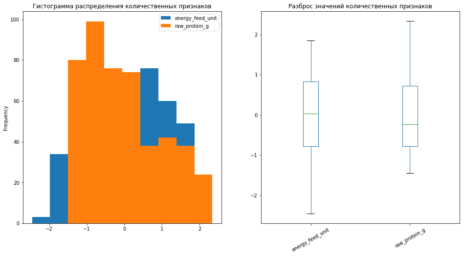

```python
# Зададим константу
RANDOM_STATE = 40
# Выделим в отдельные переменные входные и целевой признаки
X = main.drop('yield_kg', axis=1)
y = main['yield_kg']
# Разделим данные на тренировочные и тестовые выборки
X_train, X_test, y_train, y_test = train_test_split(X, y, random_state = RANDOM_STATE)

cat_col_names = ['sugar_protein_ratio', 'breed', 'type_pasture', 'breed_daddy', 'age']
# Создадим переменную с классом кодирования, включим параметр для избегания дамми-ошибок
encoder2 = OneHotEncoder(drop='first', sparse=False)
# Обучим и преобразуем категориальные признаки в тестовой выборке
X_train_ohe = encoder2.fit_transform(X_train[cat_col_names])
# Преобразуем категориальные признаки в тренировочной выборке
X_test_ohe = encoder2.transform(X_test[cat_col_names])

num_col_names = ['energy_feed_unit', 'raw_protein_g']
# Создадим переменную с классом стандартизации
scaler2 = StandardScaler()
# Обучим и преобразуем количественные признаки в тестовой выборке
X_train_scaler = scaler2.fit_transform(X_train[num_col_names])
# Преобразуем количественные признаки в тренировочной выборке
X_test_scaler = scaler2.transform(X_test[num_col_names])

# Выведем список новых столбцов после кодирования
encoder_col_names = encoder2.get_feature_names()

X_train_ohe = pd.DataFrame(X_train_ohe, columns=encoder_col_names)
X_test_ohe = pd.DataFrame(X_test_ohe, columns=encoder_col_names)

X_train_scaler = pd.DataFrame(X_train_scaler, columns=num_col_names)
X_test_scaler = pd.DataFrame(X_test_scaler, columns=num_col_names)

X_train = pd.concat([X_train_ohe, X_train_scaler], axis=1)
X_test = pd.concat([X_test_ohe, X_test_scaler], axis=1)

# Убедимся в правильности выполнения масштабирования.
fig, axes = plt.subplots(nrows=1, ncols=2, figsize=(16,8))
X_train_scaler.plot(kind='hist', bins=10, ax=axes[0])
axes[0].set_title('Гистограмма распределения количественных признаков')
X_train_scaler.plot(kind='box', ax=axes[1], rot=30)
axes[1].set_title('Разброс значений количественных признаков')
plt.show()
```

```python
# Инициализируем модель линейной регрессии
model_lr = LinearRegression()
model_lr.fit(X_train, y_train)
# Получим предсказания модели на тестовых данных
predictions2 = model_lr.predict(X_test)
```

```python
# Рассчитаем коэффициент детерминации
r2_2 = r2_score(y_test, predictions2)
print("Коэффициент детерминации второй модели =", r2_2)
```

```
Коэффициент детерминации второй модели = 0.8133155672894217
```

Полученный коээфициент детерминации говорит о том, что модель хорошо себя показывает в 81% предсказаний.

**Проведем анализ остатков второй модели.**

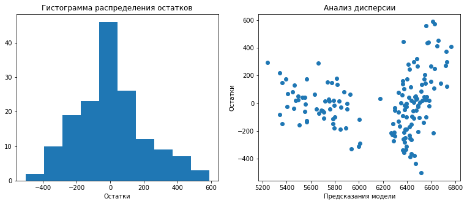

```python
# Рассчитайте остатки
residuals2 = y_test - predictions2
# Построим графики по количественным признакам - гистограмму частотности расперделения и диаграмму рассеяния
fig, axes = plt.subplots(nrows=1, ncols=2, figsize=(13,5))
axes[0].hist(residuals2)
axes[0].set_title('Гистограмма распределения остатков')
axes[0].set_xlabel('Остатки')

axes[1].scatter(x = predictions2, y = residuals2)
axes[1].set_title('Анализ дисперсии')
axes[1].set_xlabel('Предсказания модели')
axes[1].set_ylabel('Остатки')
plt.show()
```

Гистограмма распределения остатков показывает что среднее и медиана совпадают, но распределение не нормальное (бимодальности, плюс смещение среднего влево от нуля), то есть у модели нестабильная ошибка в большинстве предсказаний. По анализу дисперсии можно сказать, что разброс остатков более склонен к непостоянству. Но разница дисперсии ошибок не систематиченская, а выборочная. Модель стоит улучшать.

**Оценим качество второй модели - рассчитаем метрики MSE, MAE, RMSE**

```python
mse2 = mean_squared_error(y_test, predictions2)
mae2 = mean_absolute_error(y_test, predictions2)
rmse2 = mean_squared_error(y_test, predictions2, squared=False)
print(f"MSE второй модели = {mse2:.2f}")
print(f"MAE второй модели = {mae2:.2f}")
print(f"RMSE второй модели = {rmse2:.2f}")
```

```
MSE второй модели = 42482.91
MAE второй модели = 157.09
RMSE второй модели = 206.11
```

В среднем, вторая модель ошибается, примерно, на 157.09 - 206.11 кг.

### Подготовим данные и обучим на них третью модель `LinearRegression`

Для третий модели будем использовать датасет `main_dad` с признаком "Имя папы", с учетом преобразованых данных (СПО, ЭКЕ) второй модели.

```python
main_dad['sugar_protein_ratio'] = main_dad.apply(categorise, axis=1)
main_dad['energy_feed_unit'] = main_dad['energy_feed_unit']**2
```

После того, как мы доработали данные, приступим к созданию третий модели.

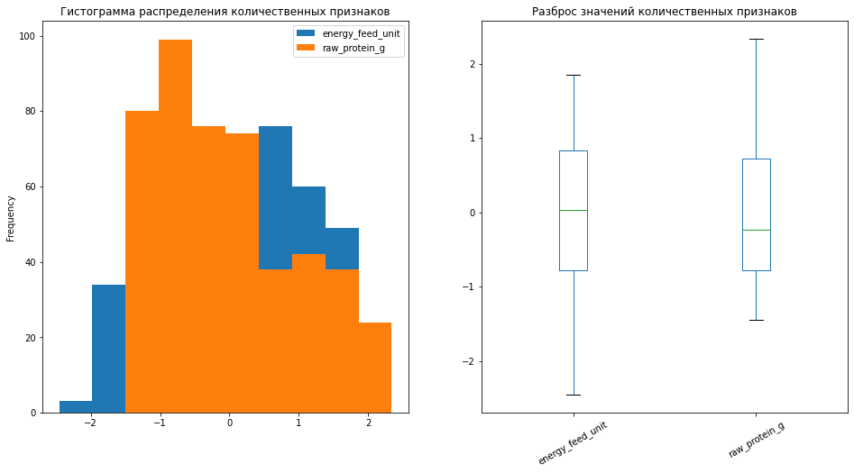

```python
# Зададим константу
RANDOM_STATE = 40
# Выделим в отдельные переменные входные и целевой признаки
X = main_dad.drop('yield_kg', axis=1)
y = main_dad['yield_kg']
# Разделим данные на тренировочные и тестовые выборки
X_train, X_test, y_train, y_test = train_test_split(X, y, random_state = RANDOM_STATE)

cat_col_names = ['sugar_protein_ratio', 'breed', 'type_pasture', 'breed_daddy', 'name_daddy']
# Создадим переменную с классом кодирования, включим параметр для избегания дамми-ошибок
encoder3 = OneHotEncoder(drop='first', sparse=False)
# Обучим и преобразуем категориальные признаки в тестовой выборке
X_train_ohe = encoder3.fit_transform(X_train[cat_col_names])
# Преобразуем категориальные признаки в тренировочной выборке
X_test_ohe = encoder3.transform(X_test[cat_col_names])

num_col_names = ['energy_feed_unit', 'raw_protein_g']
# Создадим переменную с классом стандартизации
scaler3 = StandardScaler()
# Обучим и преобразуем количественные признаки в тестовой выборке
X_train_scaler = scaler3.fit_transform(X_train[num_col_names])
# Преобразуем количественные признаки в тренировочной выборке
X_test_scaler = scaler3.transform(X_test[num_col_names])

# Выведем список новых столбцов после кодирования
encoder_col_names = encoder3.get_feature_names()

X_train_ohe = pd.DataFrame(X_train_ohe, columns=encoder_col_names)
X_test_ohe = pd.DataFrame(X_test_ohe, columns=encoder_col_names)

X_train_scaler = pd.DataFrame(X_train_scaler, columns=num_col_names)
X_test_scaler = pd.DataFrame(X_test_scaler, columns=num_col_names)

X_train = pd.concat([X_train_ohe, X_train_scaler], axis=1)
X_test = pd.concat([X_test_ohe, X_test_scaler], axis=1)

# Убедимся в правильности выполнения масштабирования.
fig, axes = plt.subplots(nrows=1, ncols=2, figsize=(16,8))
X_train_scaler.plot(kind='hist', bins=10, ax=axes[0])
axes[0].set_title('Гистограмма распределения количественных признаков')
X_train_scaler.plot(kind='box', ax=axes[1], rot=30)
axes[1].set_title('Разброс значений количественных признаков')
plt.show()
```

```python
# Инициализируем модель линейной регрессии
model_lr = LinearRegression()
model_lr.fit(X_train, y_train)
# Получим предсказания модели на тестовых данных
predictions3 = model_lr.predict(X_test)
```

```python
# Рассчитаем коэффициент детерминации
r2_3 = r2_score(y_test, predictions3)
print("Коэффициент детерминации третий модели =", r2_3)
```

```
Коэффициент детерминации третий модели = 0.8224355885553215
```

Полученный коээфициент детерминации говорит о том, что модель хорошо себя показывает в 82.2% предсказаний.

**Проведем анализ остатков третий модели.**

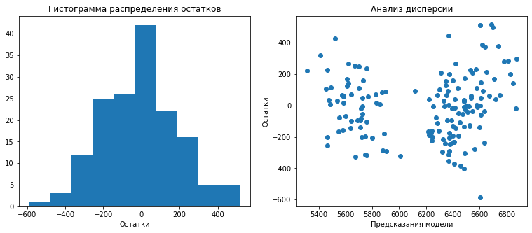

```python
# Рассчитайте остатки
residuals3 = y_test - predictions3
# Построим графики по количественным признакам - гистограмму частотности расперделения и диаграмму рассеяния
fig, axes = plt.subplots(nrows=1, ncols=2, figsize=(13,5))
axes[0].hist(residuals3)
axes[0].set_title('Гистограмма распределения остатков')
axes[0].set_xlabel('Остатки')

axes[1].scatter(x = predictions3, y = residuals3)
axes[1].set_title('Анализ дисперсии')
axes[1].set_xlabel('Предсказания модели')
axes[1].set_ylabel('Остатки')
plt.show()
```

Гистограмма распределения остатков показывает что распределение похожее на нормальное, с небольшой ассиметрией остатков, то есть у модели стабильная ошибка в большинстве предсказаний. По анализу дисперсии можно сказать, что разброс остатков стал иметь более равномерный вид, но также присутствует склоность к непостоянству, которое выражено пустотой на интервале [6000;6200] по оси Х, т.е. остатки - гомоскедастичны. Значит модель можно использовать для прогноза.

Потенциал для улучшения модели всё ещё есть, но на текущий момент признаём модель качественной (остатки гомоскедастичны) и пригодной для работы

**Оценим качество третий модели - рассчитаем метрики MSE, MAE, RMSE**

```python
mse3 = mean_squared_error(y_test, predictions3)
mae3 = mean_absolute_error(y_test, predictions3)
rmse3 = mean_squared_error(y_test, predictions3, squared=False)
print(f"MSE третий модели = {mse3:.2f}")
print(f"MAE третий модели = {mae3:.2f}")
print(f"RMSE третий модели = {rmse3:.2f}")
```

```
MSE третий модели = 40407.51
MAE третий модели = 159.25
RMSE третий модели = 201.02
```

В среднем, третья модель ошибается, примерно, на 159.25 - 201.02 кг.

Определим доверительный интервал прогноза лучшей модели

```python
print(st.norm.interval(confidence=0.95, loc=np.mean(predictions3), scale=st.sem(predictions3)))
print(st.norm.interval(confidence=0.99, loc=np.mean(predictions3), scale=st.sem(predictions3)))
```

```
(6122.053500127949, 6253.325144903506)
(6101.429229982116, 6273.949415049338)
```

Получается, что в 95% случаев, мы имеем прогнозный удой в интервале 6122-6253 кг в год. А в 99% случаев мы имеем удой в интервале 6101-6273 кг в год.

### Сравним качество трёх моделей линейной регрессии, сопоставим их R² и остатки.

Для того, чтобы оценить качество трех моделй, составим сводную таблицу с полученными метриками трех моделей.

```python
R2 = [r2_1, r2_2, r2_3]
R2_index = ['Модель №1', 'Модель №2', 'Модель №3']
R2_columns = ['R2']
R2 = pd.DataFrame(R2, index=R2_index, columns=R2_columns)
```

```python
R2.head()
```

|  | R2 |
| --- | --- |
| Модель №1 | 0.805457 |
| Модель №2 | 0.813316 |
| Модель №3 | 0.822436 |

По анализу полученных коэффициентов детерминации, наилучшей результат по предсказыванию данных имеет модель №3, она хорошо себя показывает в 82% предсказаний.

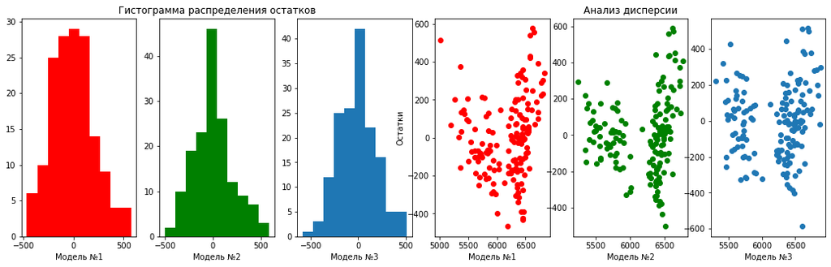

```python
fig, axes = plt.subplots(nrows=1, ncols=6, figsize=(18,5))
axes[0].hist(residuals1, color='red')
axes[1].hist(residuals2, color='green')
axes[2].hist(residuals3)
axes[1].set_title('Гистограмма распределения остатков')
axes[0].set_xlabel('Модель №1')
axes[1].set_xlabel('Модель №2')
axes[2].set_xlabel('Модель №3')

axes[3].scatter(x = predictions1, y = residuals1, color='red')
axes[4].scatter(x = predictions2, y = residuals2, color='green')
axes[5].scatter(x = predictions3, y = residuals3)
axes[4].set_title('Анализ дисперсии')
axes[3].set_ylabel('Остатки')
axes[3].set_xlabel('Модель №1')
axes[4].set_xlabel('Модель №2')
axes[5].set_xlabel('Модель №3')

plt.show()
```

По анализу гистограмм распределения, наиболее близкое к нормальному распределению остатков имеет модель №3.

По анализу дисперсии остатков, можно выделить первую и третью модели. У первой модели остатки распредлены более равнормерно, но имеются выбросы. У третий модели выбросов наблюдается меньше, но присутствует непостоянство в виде пустоты на диаграмме на интервале [6000;6200] по оси Х.

### Оценим качество каждой модели по трём метрикам: MSE, MAE, RMSE

Для того, чтобы оценить качество трех моделй, составим сводную таблицу с полученными метриками трех моделей.

```python
metrics = [[mse1, mse2, mse3], [mae1, mae2, mae3], [rmse1, rmse2, rmse3]]
metrics_columns = ['Модель №1', 'Модель №2', 'Модель №3']
metrics_index = ['MSE', 'MAE', 'RMSE']
metrics = pd.DataFrame(metrics, index=metrics_index, columns=metrics_columns)
```

```python
metrics
```

|  | Модель №1 | Модель №2 | Модель №3 |
| --- | --- | --- | --- |
| MSE | 44271.233132 | 42482.911389 | 40407.510405 |
| MAE | 167.778720 | 157.093996 | 159.253141 |
| RMSE | 210.407303 | 206.113831 | 201.016194 |

### С помощью лучшей модели спрогнозируем удой коров, которых фермер хочет купить.

На основе полученной лучшей модели №3 спрогнозируем удой коров, которых фермер хочет купить по данным, которые находятся в датасете `cow_buy`.

Для этого добавим добавим в данный датасет недостоющие признаки: `energy_feed_unit`, `raw_protein_g`, `sugar_protein_ratio`. Возьмем эти признаки из датасета `main_dad`, взяв их средние значения и увеличив их на 5%.

```python
cow_buy['energy_feed_unit'] = main_dad['energy_feed_unit'].mean()*1.05
cow_buy['raw_protein_g'] = main_dad['raw_protein_g'].mean()*1.05
cow_buy['sugar_protein_ratio_prob'] = main['sugar_protein_ratio_prob'].mean()*1.05
```

```python
def categorise_prob(row):
    try:
        if row['sugar_protein_ratio_prob'] < 0.91:
               return "Меньше 0.91"
        else:
               return "Больше 0.91"
    except:
        pass
cow_buy['sugar_protein_ratio'] = cow_buy.apply(categorise_prob, axis=1)
```

```python
cow_buy.tail(3)
```

|  | breed | type_pasture | breed_daddy | name_daddy | fat_perc | protein_perc | energy_feed_unit | raw_protein_g | sugar_protein_ratio_prob | sugar_protein_ratio |
| --- | --- | --- | --- | --- | --- | --- | --- | --- | --- | --- |
| 16 | Вис Бик Айдиал | холмистое | Соверин | Соловчик | 3.73 | 3.079 | 224.025225 | 2019.947532 | 0.958744 | Больше 0.91 |
| 17 | РефлешнСоверинг | равнинное | Соверин | Геркулес | 3.77 | 3.053 | 224.025225 | 2019.947532 | 0.958744 | Больше 0.91 |
| 18 | Вис Бик Айдиал | равнинное | Соверин | Буйный | 3.34 | 3.069 | 224.025225 | 2019.947532 | 0.958744 | Больше 0.91 |

Выполните подготовку данных, аналогичную той, которую делали для тренировочной выборки и получим прогноз удоя.

```python
X_cow_buy_ohe = encoder3.transform(cow_buy[cat_col_names])
X_cow_buy_scaler = scaler3.transform(cow_buy[num_col_names])

X_cow_buy_ohe = pd.DataFrame(X_cow_buy_ohe, columns=encoder_col_names)
X_cow_buy_scaler = pd.DataFrame(X_cow_buy_scaler, columns=num_col_names)
X_cow_buy = pd.concat([X_cow_buy_ohe, X_cow_buy_scaler], axis=1)
```

```python
# Получим предсказания модели на данных датасета cow_buy
predictions_cow_buy = model_lr.predict(X_cow_buy)
```

```python
cow_buy['predictions_yield_kg'] = predictions_cow_buy
```

Выведем датасет с прогнозным значением удоя коров.

```python
cow_buy.head()
```

|  | breed | type_pasture | breed_daddy | name_daddy | fat_perc | protein_perc | energy_feed_unit | raw_protein_g | sugar_protein_ratio_prob | sugar_protein_ratio | predictions_yield_kg |
| --- | --- | --- | --- | --- | --- | --- | --- | --- | --- | --- | --- |
| 0 | Вис Бик Айдиал | холмистое | Айдиал | Геркулес | 3.58 | 3.076 | 224.025225 | 2019.947532 | 0.958744 | Больше 0.91 | 6575.188595 |
| 1 | Вис Бик Айдиал | равнинное | Соверин | Буйный | 3.54 | 3.081 | 224.025225 | 2019.947532 | 0.958744 | Больше 0.91 | 6493.456405 |
| 2 | РефлешнСоверинг | равнинное | Соверин | Барин | 3.59 | 3.074 | 224.025225 | 2019.947532 | 0.958744 | Больше 0.91 | 6253.161178 |
| 3 | РефлешнСоверинг | холмистое | Айдиал | Буйный | 3.40 | 3.061 | 224.025225 | 2019.947532 | 0.958744 | Больше 0.91 | 6558.023499 |
| 4 | РефлешнСоверинг | равнинное | Айдиал | Буйный | 3.64 | 3.074 | 224.025225 | 2019.947532 | 0.958744 | Больше 0.91 | 6504.470859 |

```python
cow_buy_predictions = cow_buy[cow_buy['predictions_yield_kg']>6000]
cow_buy_predictions.shape
```

```
(16, 11)
```

По прогнозам получилось, что удой больше 6000 кг в год имеет 16 коров.

## Обучение модели логистической регрессии

На данном этапе необходимо выполнить следующие шаги:

- Подготовить данные датасета и обучить на них модель `LogisticRegression`.
- Проанализировать модель логистической регрессии.
- С помощью обученной модели спрогнозировать вкус молока коров, которых фермер хочет купить. Данные о них находятся в датасете `cow_buy`.

### Подготовим данные датасета и обучим на них модель `LogisticRegression`.

```python
main.head(3)
```

|  | id | yield_kg | energy_feed_unit | raw_protein_g | sugar_protein_ratio | breed | type_pasture | breed_daddy | fat_perc | protein_perc | taste_milk | age | sugar_protein_ratio_prob |
| --- | --- | --- | --- | --- | --- | --- | --- | --- | --- | --- | --- | --- | --- |
| 0 | 1 | 5863 | 201.64 | 1743 | Меньше 0.91 | Вис Бик Айдиал | равнинное | Айдиал | 3.58 | 3.076 | вкусно | более_2_лет | 0.890 |
| 1 | 2 | 5529 | 163.84 | 2138 | Меньше 0.91 | Вис Бик Айдиал | равнинное | Соверин | 3.54 | 3.079 | вкусно | менее_2_лет | 0.890 |
| 2 | 3 | 5810 | 196.00 | 1854 | Меньше 0.91 | РефлешнСоверинг | холмистое | Соверин | 3.59 | 3.074 | не вкусно | более_2_лет | 0.885 |

```python
# Зададим константу
RANDOM_STATE = 40
# Выделим в отдельные переменные входные и целевой признаки
X = main.drop('taste_milk', axis=1)
y = main['taste_milk']
# Разделим данные на тренировочные и тестовые выборки
X_train, X_test, y_train, y_test = train_test_split(X, y, random_state = RANDOM_STATE)

cat_col_names = ['sugar_protein_ratio', 'breed', 'type_pasture', 'breed_daddy']
encoder = OneHotEncoder(drop='first', sparse=False)
X_train_ohe = encoder.fit_transform(X_train[cat_col_names])
X_test_ohe = encoder.transform(X_test[cat_col_names])

num_col_names = ['energy_feed_unit', 'raw_protein_g', 'fat_perc', 'protein_perc']
scaler = StandardScaler()
X_train_scaler = scaler.fit_transform(X_train[num_col_names])
X_test_scaler = scaler.transform(X_test[num_col_names])

encoder_col_names = encoder.get_feature_names()

X_train_ohe = pd.DataFrame(X_train_ohe, columns=encoder_col_names)
X_test_ohe = pd.DataFrame(X_test_ohe, columns=encoder_col_names)

X_train_scaler = pd.DataFrame(X_train_scaler, columns=num_col_names)
X_test_scaler = pd.DataFrame(X_test_scaler, columns=num_col_names)

X_train = pd.concat([X_train_ohe, X_train_scaler], axis=1)
X_test = pd.concat([X_test_ohe, X_test_scaler], axis=1)
```

```python
# Инициализируем модель логистической регрессии
clf = LogisticRegression()
clf.fit(X_train, y_train)
# Получим предсказания модели на тестовых данных
predictions = clf.predict(X_test)
```

Оценим качество модели на тестовой выборке: рассчитаем метрики accuracy, recall, precision.

```python
acc = accuracy_score(y_test, predictions)
print(f"Точность модели по accuracy - {acc:.3f}")
precision = precision_score(y_test, predictions, pos_label='вкусно')
print(f"Точность модели по precision - {precision:.3f}")
recall = recall_score(y_test, predictions, pos_label='вкусно')
print(f"Полнота модели по recall - {recall:.3f}")
```

```
Точность модели по accuracy - 0.624
Точность модели по precision - 0.655
Полнота модели по recall - 0.800
```

Построим матрицу ошибок

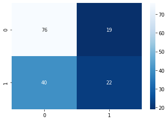

```python
cm = confusion_matrix(y_test, predictions)
sns.heatmap(cm, annot=True, fmt='d', cmap='Blues_r')
plt.show()
```

### Проанализируем модель логистической регрессии.

Главная задача для заказчика — вкусное молоко. Поэтому, в нашем случае, критичнее ошибка будет первого рода, когда истиное значение "не вкусно", а модель предсказывает "вкусно". Получается, важнее для данной задачи метрика - precision.

По умолчанию модель относит все предсказания с оценкой 0.5 и выше к классу "1", а ниже 0.5 - к классу "0". Необходимо настроить данный порог, чтобы модель точнее присваивала один из классов.

```python
# THRESHOLD = [round(i,2) for i in np.linspace(0.1,1,num=13, endpoint=False)]
THRESHOLD = 0.73
preds = np.where(clf.predict_proba(X_test)[:,1] > THRESHOLD, 'не вкусно', 'вкусно')
```

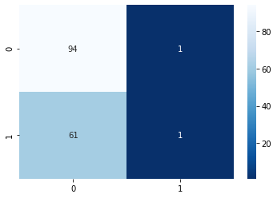

```python
cm = confusion_matrix(y_test, preds)
sns.heatmap(cm, annot=True, fmt='d', cmap='Blues_r')
plt.show()
```

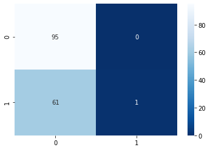

```python
THRESHOLD = 0.74
preds = np.where(clf.predict_proba(X_test)[:,1] > THRESHOLD, 'не вкусно', 'вкусно')

cm = confusion_matrix(y_test, preds)
sns.heatmap(cm, annot=True, fmt='d', cmap='Blues_r')
plt.show()
```

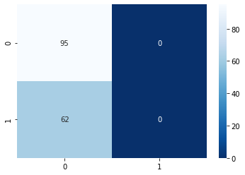

```python
THRESHOLD = 0.75
preds = np.where(clf.predict_proba(X_test)[:,1] > THRESHOLD, 'не вкусно', 'вкусно')

cm = confusion_matrix(y_test, preds)
sns.heatmap(cm, annot=True, fmt='d', cmap='Blues_r')
plt.show()
```

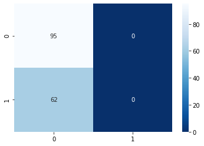

```python
THRESHOLD = 0.76
preds = np.where(clf.predict_proba(X_test)[:,1] > THRESHOLD, 'не вкусно', 'вкусно')

cm = confusion_matrix(y_test, preds)
sns.heatmap(cm, annot=True, fmt='d', cmap='Blues_r')
plt.show()
```

```python
precision_proba = precision_score(y_test, preds, pos_label='вкусно')
print(f"Точность модели по precision - {precision_proba:.3f}")
recall_proba = recall_score(y_test, preds, pos_label='вкусно')
print(f"Полнота модели по recall - {recall_proba:.3f}")
```

```
Точность модели по precision - 0.605
Полнота модели по recall - 1.000
```

Путем подбора порога принадлежности к классам, мы выявили:

- при пороге равном 0.73 ошибки ТP и FP равны 1;
- при пороге 0.74 ошибка FP сводится к нулю, ошибка ТP равна 1;
- при пороге 0.75 и выше обе ошибки ТP и FP сводятся к нулю.

### С помощью обученной модели спрогнозируем вкус молока коров, которых фермер хочет купить.

```python
X_cow_buy_ohe = encoder.transform(cow_buy[cat_col_names])
X_cow_buy_scaler = scaler.transform(cow_buy[num_col_names])

X_cow_buy_ohe = pd.DataFrame(X_cow_buy_ohe, columns=encoder_col_names)
X_cow_buy_scaler = pd.DataFrame(X_cow_buy_scaler, columns=num_col_names)
X_cow_buy = pd.concat([X_cow_buy_ohe, X_cow_buy_scaler], axis=1)
```

```python
clf = LogisticRegression()
clf.fit(X_train, y_train)
predictions_cow_buy = clf.predict(X_cow_buy)
```

Выведем датасет с прогнозным показателем вкуса молока.

```python
cow_buy['predictions_taste'] = predictions_cow_buy
cow_buy.head(3)
```

|  | breed | type_pasture | breed_daddy | name_daddy | fat_perc | protein_perc | energy_feed_unit | raw_protein_g | sugar_protein_ratio_prob | sugar_protein_ratio | predictions_yield_kg | predictions_taste |
| --- | --- | --- | --- | --- | --- | --- | --- | --- | --- | --- | --- | --- |
| 0 | Вис Бик Айдиал | холмистое | Айдиал | Геркулес | 3.58 | 3.076 | 224.025225 | 2019.947532 | 0.958744 | Больше 0.91 | 6575.188595 | вкусно |
| 1 | Вис Бик Айдиал | равнинное | Соверин | Буйный | 3.54 | 3.081 | 224.025225 | 2019.947532 | 0.958744 | Больше 0.91 | 6493.456405 | вкусно |
| 2 | РефлешнСоверинг | равнинное | Соверин | Барин | 3.59 | 3.074 | 224.025225 | 2019.947532 | 0.958744 | Больше 0.91 | 6253.161178 | не вкусно |

## Итоговые выводы

Выведем датасет с прогнозами вкуса молока и удоя коров «ЭкоФермы» в датафрейм с коровами, покупку которых рассматривает фермер.

```python
cow_buy.head()
```

|  | breed | type_pasture | breed_daddy | name_daddy | fat_perc | protein_perc | energy_feed_unit | raw_protein_g | sugar_protein_ratio_prob | sugar_protein_ratio | predictions_yield_kg | predictions_taste |
| --- | --- | --- | --- | --- | --- | --- | --- | --- | --- | --- | --- | --- |
| 0 | Вис Бик Айдиал | холмистое | Айдиал | Геркулес | 3.58 | 3.076 | 224.025225 | 2019.947532 | 0.958744 | Больше 0.91 | 6575.188595 | вкусно |
| 1 | Вис Бик Айдиал | равнинное | Соверин | Буйный | 3.54 | 3.081 | 224.025225 | 2019.947532 | 0.958744 | Больше 0.91 | 6493.456405 | вкусно |
| 2 | РефлешнСоверинг | равнинное | Соверин | Барин | 3.59 | 3.074 | 224.025225 | 2019.947532 | 0.958744 | Больше 0.91 | 6253.161178 | не вкусно |
| 3 | РефлешнСоверинг | холмистое | Айдиал | Буйный | 3.40 | 3.061 | 224.025225 | 2019.947532 | 0.958744 | Больше 0.91 | 6558.023499 | не вкусно |
| 4 | РефлешнСоверинг | равнинное | Айдиал | Буйный | 3.64 | 3.074 | 224.025225 | 2019.947532 | 0.958744 | Больше 0.91 | 6504.470859 | не вкусно |

Отберем коров, для которых спрогнозирован удой более 6000 килограммов в год и вкусное молоко.

```python
cow_buy_selected = cow_buy[(cow_buy['predictions_yield_kg']>6000) & (cow_buy['predictions_taste'] == 'вкусно')]
```

```python
cow_buy_selected.shape
```

```
(6, 12)
```

**Результаты работы моделей для фермера**

По получившимся данным, 6 коров фермер может купить из стада на продажу с минимальным риском для себя. Молоко от таких коров получается по предсказаниям вкусным, а удой составляет более 6000 кг, что является выше среднего годового показателя удоя коровы в год. Также фермеру стоит обращать внимание и на другие признаки, которые влияют на удой и на вкус коровы.

**Выводы о моделях линейной регрессии и логистической регрессии:**

- Для улучшения качества регрессионной модели мы исключили нелинейность, чтобы эти признаки были информативны для линейной регрессии, а также добавили новый признак.
- Улучшить результаты регрессионной модели можно с добавлением новых признаков. Возможно необходимо еще расссмотреть признаки, влияющие на удой коровы: условия содержания коров, сезона года, живой массы, состояния здоровья коровы. Так же признаки, влияющие на вкус молока: соблюдение гигиены при уходе за животным, болезни коровы и стельность.
- При анализе рисков или экономических расчётов важны такие метрики как точность модели и полнота модели. Точность модели показывает, насколько верно модель предсказывает результаты. А полнота модели показывает, сколько положительных результатов модель смогла предсказать. Метрики важны при анализе рисков или экономических расчетов, так как они позволяют оценить, насколько хорошо работает модель и насколько можно ей доверять.